# Assignment 12: Predictive Modeling - Part 3

*How to do it?*:

- Open the Rmarkdown file of this assignment (link) in Rstudio.
- Right under each **question**, insert a code chunk (you can use the hotkey `Ctrl + Alt + I` to add a code chunk) and code the solution for the question.
- `Knit` the rmarkdown file (hotkey: `Ctrl + Alt + K`) to export an html.
- Publish the html file to your Githiub Page.

*Submission*: Submit the link on Github of the assignment to Blackboard.

```r
library(tidyverse)
library(caret)
library(mlbench)
```

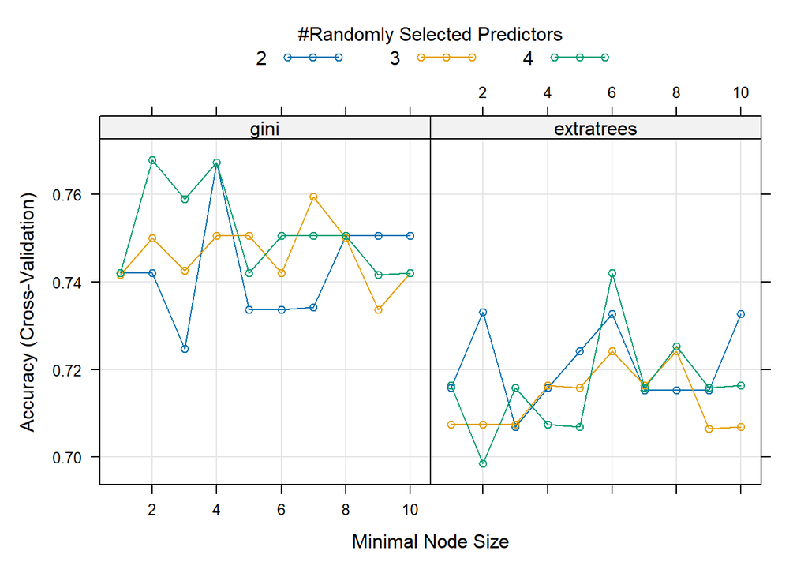

```r
data("PimaIndiansDiabetes", package = "mlbench")

df = PimaIndiansDiabetes

df <- df %>% rename(target=diabetes)

splitIndex <- createDataPartition(df$target, p = .15,
                                  list = FALSE)
df_train <- df[ splitIndex,]
df_test <- df[-splitIndex,]

trControl = trainControl(method = "cv",
                         number = 7)
tuneGrid = expand.grid(mtry = 2:4,
                       splitrule = c('gini', 'extratrees'),
                       min.node.size = c(1:10))
forest_ranger <- train(target~., data=df_train,
                    method = "ranger",
                    trControl = trControl,
                    tuneGrid = tuneGrid)

plot(forest_ranger)
```

```r
forest_ranger
```

```
## Random Forest
##
## 116 samples
##   8 predictor
##   2 classes: 'neg', 'pos'
##
## No pre-processing
## Resampling: Cross-Validated (7 fold)
## Summary of sample sizes: 99, 100, 99, 99, 100, 100, ...
## Resampling results across tuning parameters:
##
##   mtry  splitrule   min.node.size  Accuracy   Kappa
##   2     gini         1             0.7421218  0.3953407
##   2     gini         2             0.7421218  0.3953407
##   2     gini         3             0.7247899  0.3569167
```

[output cut: 61 more lines]

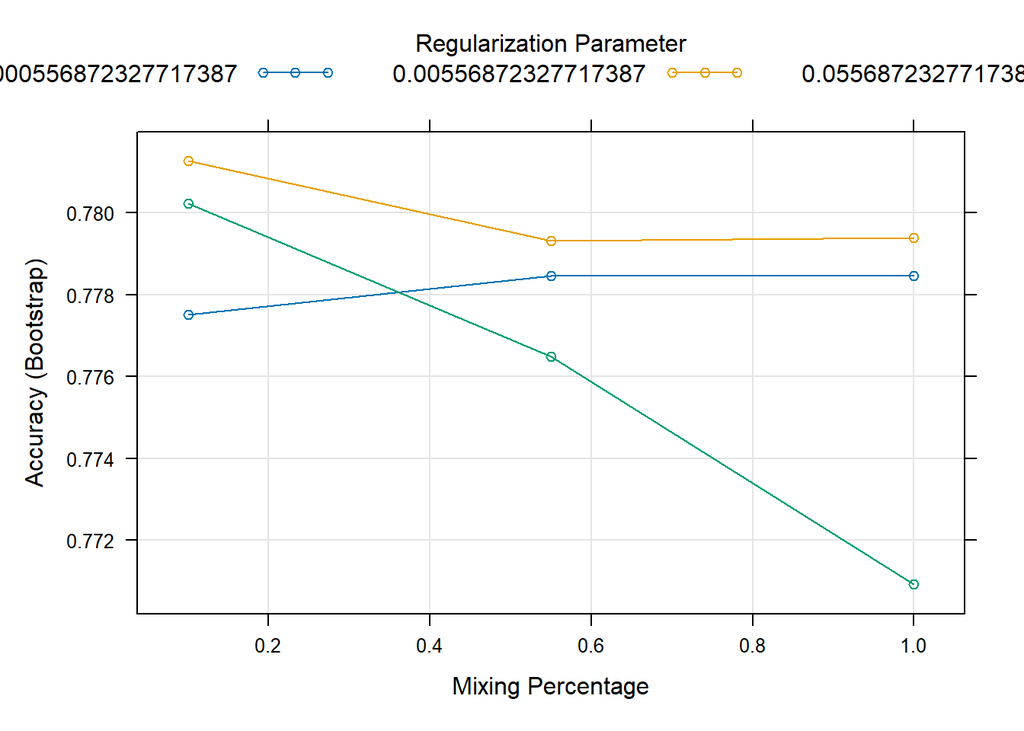

```r
library(tidyverse)
library(caret)

df = PimaIndiansDiabetes

df <- df %>% rename(target=diabetes)

splitIndex <- createDataPartition(df$target, p = .15,
                                  list = FALSE)
df_train <- df[ splitIndex,]
df_test <- df[-splitIndex,]

trControl = trainControl(method = "cv",
                         number = 7)
tuneGrid = expand.grid(mtry = 2:4,
                       splitrule = c('gini', 'extratrees'),
                       min.node.size = c(1:10))
forest_ranger <- train(target~., data=df_train,
                    method = "glmnet")

plot(forest_ranger)
```

```r
forest_ranger
```

```
## glmnet
##
## 116 samples
##   8 predictor
##   2 classes: 'neg', 'pos'
##
## No pre-processing
## Resampling: Bootstrapped (25 reps)
## Summary of sample sizes: 116, 116, 116, 116, 116, 116, ...
## Resampling results across tuning parameters:
##
##   alpha  lambda        Accuracy   Kappa
##   0.10   0.0005568723  0.7775094  0.4959501
##   0.10   0.0055687233  0.7812605  0.5036681
##   0.10   0.0556872328  0.7802350  0.4912569
##   0.55   0.0005568723  0.7784618  0.4982311
##   0.55   0.0055687233  0.7793240  0.4989131
##   0.55   0.0556872328  0.7764950  0.4736449
##   1.00   0.0005568723  0.7784618  0.4982311
##   1.00   0.0055687233  0.7793960  0.4978935
##   1.00   0.0556872328  0.7709230  0.4580770
##
## Accuracy was used to select the optimal model using the largest value.
## The final values used for the model were alpha = 0.1 and lambda = 0.005568723.
```

3. (Model Comparison) Use the `PimaIndiansDiabetes` dataset. Pick two models at [this link](https://topepo.github.io/caret/available-models.html) to compare using 7-fold cross validation method. Evaluate the accuracy of the final model on the test data.

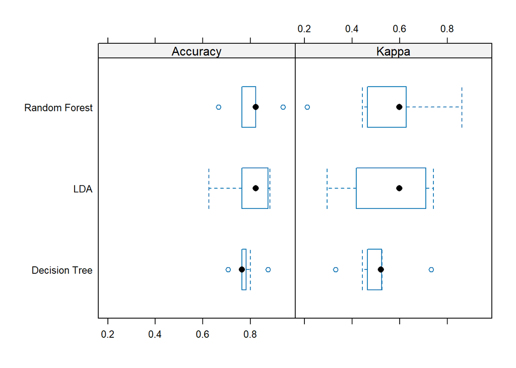

```r
trControl = trainControl(method = "cv",
                         number = 7)
tree <- train(target~., data=df_train,
                                method = "rpart2",
                                trControl = trControl)
forest_ranger <- train(target~., data=df_train,
                    method = "rf",
                                trControl = trControl)
lda <- train(target~., data=df_train,
                                method = "lda",
                                trControl = trControl)
results <- resamples(list('Decision Tree' = tree,
                          'Random Forest' = forest_ranger,
                          'LDA'= lda))
bwplot(results)
```

```r
pred <- predict(forest_ranger, df_test)
cm <- confusionMatrix(data = pred, reference = df_test$target, positive = "pos")
cm$overall[1]
```

```
##  Accuracy
## 0.7177914
```